# Risk Factor Analysis

## Outcome Variable

**Outcome Variable:** ever_sstunted

## Predictor Variables

**Intervention Variable:** mhtcm

**Adjustment Set:**

- arm
- W_mage
- meducyrs
- feducyrs
- hhwealth_quart
- delta_W_mage
- delta_meducyrs
- delta_feducyrs
- delta_hhwealth_quart

## Stratifying Variables

The analysis was stratified on these variable(s):

- agecat
- studyid
- country

## Data Summary

| agecat | studyid | country | mhtcm | ever_sstunted | n_cell | n |
| --- | --- | --- | --- | --- | --- | --- |
| 0-24 months | COHORTS | GUATEMALA | >=155 cm | 0 | 115 | 1292 |
| 0-24 months | COHORTS | GUATEMALA | >=155 cm | 1 | 51 | 1292 |
| 0-24 months | COHORTS | GUATEMALA | <151 cm | 0 | 412 | 1292 |
| 0-24 months | COHORTS | GUATEMALA | <151 cm | 1 | 433 | 1292 |
| 0-24 months | COHORTS | GUATEMALA | [151-155) cm | 0 | 160 | 1292 |
| 0-24 months | COHORTS | GUATEMALA | [151-155) cm | 1 | 121 | 1292 |
| 0-24 months | COHORTS | INDIA | >=155 cm | 0 | 540 | 1906 |
| 0-24 months | COHORTS | INDIA | >=155 cm | 1 | 31 | 1906 |
| 0-24 months | COHORTS | INDIA | <151 cm | 0 | 687 | 1906 |
| 0-24 months | COHORTS | INDIA | <151 cm | 1 | 137 | 1906 |
| 0-24 months | COHORTS | INDIA | [151-155) cm | 0 | 458 | 1906 |
| 0-24 months | COHORTS | INDIA | [151-155) cm | 1 | 53 | 1906 |
| 0-24 months | COHORTS | PHILIPPINES | >=155 cm | 0 | 490 | 3058 |
| 0-24 months | COHORTS | PHILIPPINES | >=155 cm | 1 | 142 | 3058 |
| 0-24 months | COHORTS | PHILIPPINES | <151 cm | 0 | 855 | 3058 |
| 0-24 months | COHORTS | PHILIPPINES | <151 cm | 1 | 694 | 3058 |
| 0-24 months | COHORTS | PHILIPPINES | [151-155) cm | 0 | 624 | 3058 |
| 0-24 months | COHORTS | PHILIPPINES | [151-155) cm | 1 | 253 | 3058 |
| 0-24 months | Guatemala BSC | GUATEMALA | >=155 cm | 0 | 32 | 235 |
| 0-24 months | Guatemala BSC | GUATEMALA | >=155 cm | 1 | 4 | 235 |
| 0-24 months | Guatemala BSC | GUATEMALA | <151 cm | 0 | 108 | 235 |
| 0-24 months | Guatemala BSC | GUATEMALA | <151 cm | 1 | 35 | 235 |
| 0-24 months | Guatemala BSC | GUATEMALA | [151-155) cm | 0 | 47 | 235 |
| 0-24 months | Guatemala BSC | GUATEMALA | [151-155) cm | 1 | 9 | 235 |
| 0-24 months | iLiNS-Zinc | BURKINA FASO | >=155 cm | 0 | 2628 | 3216 |
| 0-24 months | iLiNS-Zinc | BURKINA FASO | >=155 cm | 1 | 271 | 3216 |
| 0-24 months | iLiNS-Zinc | BURKINA FASO | <151 cm | 0 | 69 | 3216 |
| 0-24 months | iLiNS-Zinc | BURKINA FASO | <151 cm | 1 | 22 | 3216 |
| 0-24 months | iLiNS-Zinc | BURKINA FASO | [151-155) cm | 0 | 181 | 3216 |
| 0-24 months | iLiNS-Zinc | BURKINA FASO | [151-155) cm | 1 | 45 | 3216 |

[output cut: 108 more lines]

The following strata were considered:

- agecat: 0-24 months, studyid: COHORTS, country: GUATEMALA
- agecat: 0-24 months, studyid: COHORTS, country: INDIA
- agecat: 0-24 months, studyid: COHORTS, country: PHILIPPINES
- agecat: 0-24 months, studyid: Guatemala BSC, country: GUATEMALA
- agecat: 0-24 months, studyid: iLiNS-Zinc, country: BURKINA FASO
- agecat: 0-24 months, studyid: JiVitA-3, country: BANGLADESH
- agecat: 0-24 months, studyid: Keneba, country: GAMBIA
- agecat: 0-24 months, studyid: LCNI-5, country: MALAWI
- agecat: 0-24 months, studyid: MAL-ED, country: BANGLADESH
- agecat: 0-24 months, studyid: MAL-ED, country: BRAZIL
- agecat: 0-24 months, studyid: MAL-ED, country: INDIA
- agecat: 0-24 months, studyid: MAL-ED, country: NEPAL
- agecat: 0-24 months, studyid: MAL-ED, country: PERU
- agecat: 0-24 months, studyid: MAL-ED, country: SOUTH AFRICA
- agecat: 0-24 months, studyid: MAL-ED, country: TANZANIA, UNITED REPUBLIC OF
- agecat: 0-24 months, studyid: NIH-Birth, country: BANGLADESH
- agecat: 0-24 months, studyid: NIH-Crypto, country: BANGLADESH
- agecat: 0-24 months, studyid: PROBIT, country: BELARUS
- agecat: 0-24 months, studyid: PROVIDE, country: BANGLADESH
- agecat: 0-24 months, studyid: SAS-CompFeed, country: INDIA
- agecat: 0-24 months, studyid: SAS-FoodSuppl, country: INDIA
- agecat: 0-24 months, studyid: TanzaniaChild2, country: TANZANIA, UNITED REPUBLIC OF
- agecat: 0-24 months, studyid: ZVITAMBO, country: ZIMBABWE

### Dropped Strata

Some strata were dropped due to rare outcomes:

- agecat: 0-24 months, studyid: Guatemala BSC, country: GUATEMALA
- agecat: 0-24 months, studyid: MAL-ED, country: BANGLADESH
- agecat: 0-24 months, studyid: MAL-ED, country: NEPAL

## Methods Detail

We're interested in the causal parameters $E[Y_a]$ for all values of $a \in \mathcal{A}$. These parameters represent the mean outcome if, possibly contrary to fact, we intervened to set all units to have $A=a$. Under the randomization and positivity assumptions, these are identified by the statistical parameters $\psi_a=E_W[E_{Y|A,W}(Y|A=a,W)]$. In addition, we're interested in the mean of $Y$, $E[Y]$ under no intervention (the observed mean). We will estimate these parameters by using SuperLearner to fit the relevant likelihood factors -- $E_{Y|A,W}(Y|A=a,W)$ and $p(A=a|W)$, and then updating our likelihood fit using a joint TMLE.

For unadjusted analyses ($W=\{\}$), initial likelihoods were estimated using Lrnr_glm to estimate the simple $E(Y|A)$ and Lrnr_mean to estimate $p(A)$. For adjusted analyses, a small library containing Lrnr_glmnet, Lrnr_xgboost, and Lrnr_mean was used.

Having estimated these parameters, we will then use the delta method to estimate relative risks and attributable risks relative to a prespecified baseline level of $A$.

# Results Detail

## Results Plots

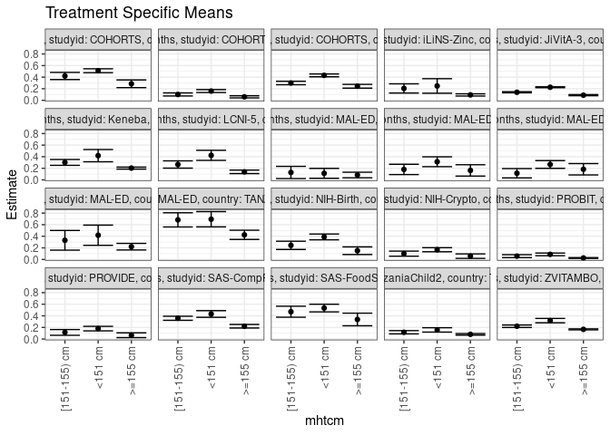

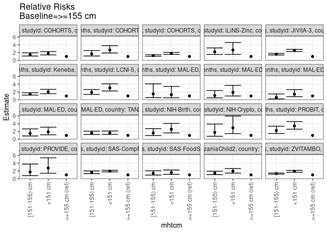

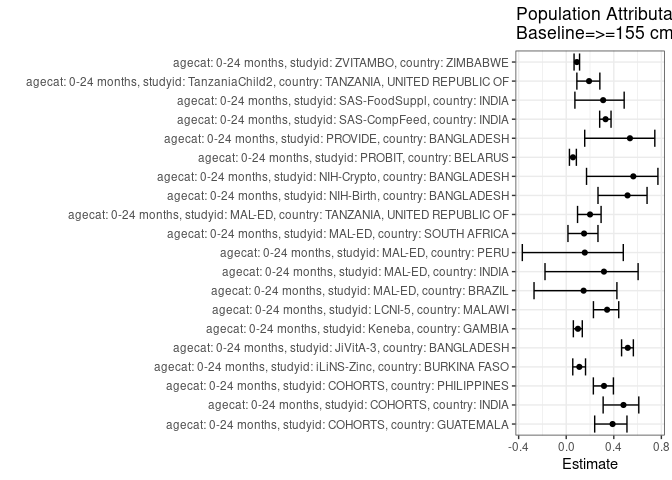

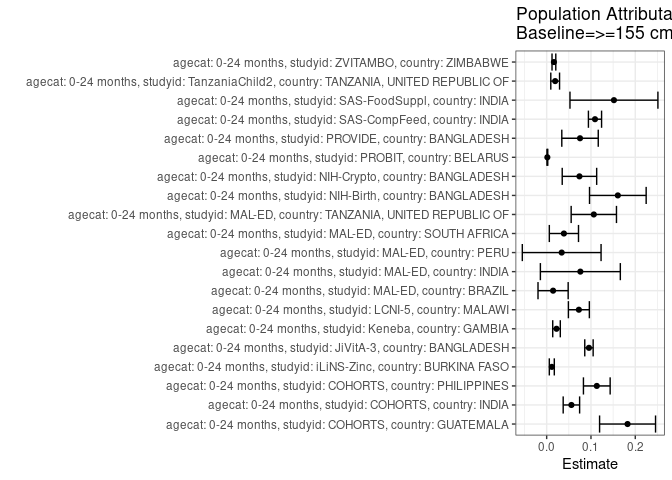

## Results Table

### Parameter: TSM

| agecat | studyid | country | intervention_level | baseline_level | estimate | ci_lower | ci_upper |
| --- | --- | --- | --- | --- | --- | --- | --- |
| 0-24 months | COHORTS | GUATEMALA | >=155 cm | NA | 0.2856704 | 0.2193617 | 0.3519791 |
| 0-24 months | COHORTS | GUATEMALA | <151 cm | NA | 0.5107757 | 0.4767787 | 0.5447727 |
| 0-24 months | COHORTS | GUATEMALA | [151-155) cm | NA | 0.4198667 | 0.3581742 | 0.4815591 |
| 0-24 months | COHORTS | INDIA | >=155 cm | NA | 0.0601245 | 0.0414918 | 0.0787572 |
| 0-24 months | COHORTS | INDIA | <151 cm | NA | 0.1600634 | 0.1347772 | 0.1853496 |
| 0-24 months | COHORTS | INDIA | [151-155) cm | NA | 0.1013990 | 0.0749991 | 0.1277990 |
| 0-24 months | COHORTS | PHILIPPINES | >=155 cm | NA | 0.2429785 | 0.2102463 | 0.2757108 |
| 0-24 months | COHORTS | PHILIPPINES | <151 cm | NA | 0.4308760 | 0.4064225 | 0.4553295 |
| 0-24 months | COHORTS | PHILIPPINES | [151-155) cm | NA | 0.2991439 | 0.2690145 | 0.3292734 |
| 0-24 months | iLiNS-Zinc | BURKINA FASO | >=155 cm | NA | 0.0935009 | 0.0742108 | 0.1127909 |
| 0-24 months | iLiNS-Zinc | BURKINA FASO | <151 cm | NA | 0.2478764 | 0.1226902 | 0.3730626 |
| 0-24 months | iLiNS-Zinc | BURKINA FASO | [151-155) cm | NA | 0.2052077 | 0.1256806 | 0.2847349 |
| 0-24 months | JiVitA-3 | BANGLADESH | >=155 cm | NA | 0.0889796 | 0.0793910 | 0.0985683 |
| 0-24 months | JiVitA-3 | BANGLADESH | <151 cm | NA | 0.2258698 | 0.2181211 | 0.2336185 |
| 0-24 months | JiVitA-3 | BANGLADESH | [151-155) cm | NA | 0.1391975 | 0.1298006 | 0.1485945 |
| 0-24 months | Keneba | GAMBIA | >=155 cm | NA | 0.2037127 | 0.1861148 | 0.2213106 |
| 0-24 months | Keneba | GAMBIA | <151 cm | NA | 0.4185875 | 0.3128342 | 0.5243408 |
| 0-24 months | Keneba | GAMBIA | [151-155) cm | NA | 0.3018344 | 0.2515185 | 0.3521504 |
| 0-24 months | LCNI-5 | MALAWI | >=155 cm | NA | 0.1387689 | 0.1089089 | 0.1686288 |
| 0-24 months | LCNI-5 | MALAWI | <151 cm | NA | 0.4237285 | 0.3367536 | 0.5107035 |
| 0-24 months | LCNI-5 | MALAWI | [151-155) cm | NA | 0.2657779 | 0.2029373 | 0.3286185 |
| 0-24 months | MAL-ED | BRAZIL | >=155 cm | NA | 0.0846154 | 0.0366660 | 0.1325648 |
| 0-24 months | MAL-ED | BRAZIL | <151 cm | NA | 0.1132075 | 0.0277128 | 0.1987022 |
| 0-24 months | MAL-ED | BRAZIL | [151-155) cm | NA | 0.1282051 | 0.0230438 | 0.2333664 |
| 0-24 months | MAL-ED | INDIA | >=155 cm | NA | 0.1636364 | 0.0656640 | 0.2616087 |
| 0-24 months | MAL-ED | INDIA | <151 cm | NA | 0.3130435 | 0.2281127 | 0.3979743 |
| 0-24 months | MAL-ED | INDIA | [151-155) cm | NA | 0.1805556 | 0.0915235 | 0.2695876 |
| 0-24 months | MAL-ED | PERU | >=155 cm | NA | 0.1833333 | 0.0852567 | 0.2814100 |
| 0-24 months | MAL-ED | PERU | <151 cm | NA | 0.2662722 | 0.1995170 | 0.3330274 |
| 0-24 months | MAL-ED | PERU | [151-155) cm | NA | 0.1147541 | 0.0346326 | 0.1948756 |
| 0-24 months | MAL-ED | SOUTH AFRICA | >=155 cm | NA | 0.2203389 | 0.1632008 | 0.2774771 |
| 0-24 months | MAL-ED | SOUTH AFRICA | <151 cm | NA | 0.4181418 | 0.2436561 | 0.5926275 |
| 0-24 months | MAL-ED | SOUTH AFRICA | [151-155) cm | NA | 0.3306349 | 0.1607412 | 0.5005286 |
| 0-24 months | MAL-ED | TANZANIA, UNITED REPUBLIC OF | >=155 cm | NA | 0.4248295 | 0.3454726 | 0.5041864 |
| 0-24 months | MAL-ED | TANZANIA, UNITED REPUBLIC OF | <151 cm | NA | 0.6942774 | 0.5622984 | 0.8262565 |
| 0-24 months | MAL-ED | TANZANIA, UNITED REPUBLIC OF | [151-155) cm | NA | 0.6834714 | 0.5609062 | 0.8060366 |
| 0-24 months | NIH-Birth | BANGLADESH | >=155 cm | NA | 0.1509595 | 0.0848813 | 0.2170376 |
| 0-24 months | NIH-Birth | BANGLADESH | <151 cm | NA | 0.3888140 | 0.3386343 | 0.4389938 |
| 0-24 months | NIH-Birth | BANGLADESH | [151-155) cm | NA | 0.2435177 | 0.1722929 | 0.3147424 |
| 0-24 months | NIH-Crypto | BANGLADESH | >=155 cm | NA | 0.0571429 | 0.0186681 | 0.0956176 |
| 0-24 months | NIH-Crypto | BANGLADESH | <151 cm | NA | 0.1678161 | 0.1326748 | 0.2029574 |
| 0-24 months | NIH-Crypto | BANGLADESH | [151-155) cm | NA | 0.1000000 | 0.0561448 | 0.1438552 |
| 0-24 months | PROBIT | BELARUS | >=155 cm | NA | 0.0255523 | 0.0187747 | 0.0323299 |
| 0-24 months | PROBIT | BELARUS | <151 cm | NA | 0.0875749 | 0.0645481 | 0.1106016 |
| 0-24 months | PROBIT | BELARUS | [151-155) cm | NA | 0.0570015 | 0.0317838 | 0.0822192 |
| 0-24 months | PROVIDE | BANGLADESH | >=155 cm | NA | 0.0652174 | 0.0239915 | 0.1064433 |
| 0-24 months | PROVIDE | BANGLADESH | <151 cm | NA | 0.1796247 | 0.1406387 | 0.2186106 |
| 0-24 months | PROVIDE | BANGLADESH | [151-155) cm | NA | 0.1139241 | 0.0643462 | 0.1635019 |
| 0-24 months | SAS-CompFeed | INDIA | >=155 cm | NA | 0.2206983 | 0.1899006 | 0.2514959 |
| 0-24 months | SAS-CompFeed | INDIA | <151 cm | NA | 0.4318490 | 0.3744587 | 0.4892393 |
| 0-24 months | SAS-CompFeed | INDIA | [151-155) cm | NA | 0.3581503 | 0.3231671 | 0.3931334 |
| 0-24 months | SAS-FoodSuppl | INDIA | >=155 cm | NA | 0.3371510 | 0.2283703 | 0.4459318 |
| 0-24 months | SAS-FoodSuppl | INDIA | <151 cm | NA | 0.5340575 | 0.4679199 | 0.6001951 |
| 0-24 months | SAS-FoodSuppl | INDIA | [151-155) cm | NA | 0.4708789 | 0.3760525 | 0.5657053 |
| 0-24 months | TanzaniaChild2 | TANZANIA, UNITED REPUBLIC OF | >=155 cm | NA | 0.0808393 | 0.0669884 | 0.0946901 |
| 0-24 months | TanzaniaChild2 | TANZANIA, UNITED REPUBLIC OF | <151 cm | NA | 0.1572455 | 0.1196630 | 0.1948281 |
| 0-24 months | TanzaniaChild2 | TANZANIA, UNITED REPUBLIC OF | [151-155) cm | NA | 0.1164612 | 0.0881451 | 0.1447772 |
| 0-24 months | ZVITAMBO | ZIMBABWE | >=155 cm | NA | 0.1663708 | 0.1581322 | 0.1746094 |
| 0-24 months | ZVITAMBO | ZIMBABWE | <151 cm | NA | 0.3173946 | 0.2796524 | 0.3551369 |
| 0-24 months | ZVITAMBO | ZIMBABWE | [151-155) cm | NA | 0.2205747 | 0.1989871 | 0.2421624 |

### Parameter: E(Y)

| agecat | studyid | country | intervention_level | baseline_level | estimate | ci_lower | ci_upper |
| --- | --- | --- | --- | --- | --- | --- | --- |
| 0-24 months | COHORTS | GUATEMALA | NA | NA | 0.4682663 | 0.4410469 | 0.4954857 |
| 0-24 months | COHORTS | INDIA | NA | NA | 0.1159496 | 0.1015724 | 0.1303268 |
| 0-24 months | COHORTS | PHILIPPINES | NA | NA | 0.3561151 | 0.3391405 | 0.3730897 |
| 0-24 months | iLiNS-Zinc | BURKINA FASO | NA | NA | 0.1050995 | 0.0855497 | 0.1246493 |
| 0-24 months | JiVitA-3 | BANGLADESH | NA | NA | 0.1844241 | 0.1788262 | 0.1900221 |
| 0-24 months | Keneba | GAMBIA | NA | NA | 0.2259259 | 0.2092953 | 0.2425566 |
| 0-24 months | LCNI-5 | MALAWI | NA | NA | 0.2114695 | 0.1837888 | 0.2391503 |
| 0-24 months | MAL-ED | BRAZIL | NA | NA | 0.0990991 | 0.0597055 | 0.1384927 |
| 0-24 months | MAL-ED | INDIA | NA | NA | 0.2396694 | 0.1857746 | 0.2935643 |
| 0-24 months | MAL-ED | PERU | NA | NA | 0.2172414 | 0.1696986 | 0.2647841 |
| 0-24 months | MAL-ED | SOUTH AFRICA | NA | NA | 0.2592593 | 0.2068905 | 0.3116280 |
| 0-24 months | MAL-ED | TANZANIA, UNITED REPUBLIC OF | NA | NA | 0.5312500 | 0.4700011 | 0.5924989 |
| 0-24 months | NIH-Birth | BANGLADESH | NA | NA | 0.3116057 | 0.2753823 | 0.3478292 |
| 0-24 months | NIH-Crypto | BANGLADESH | NA | NA | 0.1311258 | 0.1070332 | 0.1552185 |
| 0-24 months | PROBIT | BELARUS | NA | NA | 0.0270861 | 0.0199367 | 0.0342354 |
| 0-24 months | PROVIDE | BANGLADESH | NA | NA | 0.1405082 | 0.1141551 | 0.1668613 |
| 0-24 months | SAS-CompFeed | INDIA | NA | NA | 0.3297797 | 0.2987556 | 0.3608038 |
| 0-24 months | SAS-FoodSuppl | INDIA | NA | NA | 0.4889976 | 0.4404930 | 0.5375021 |
| 0-24 months | TanzaniaChild2 | TANZANIA, UNITED REPUBLIC OF | NA | NA | 0.1000424 | 0.0879314 | 0.1121534 |
| 0-24 months | ZVITAMBO | ZIMBABWE | NA | NA | 0.1827040 | 0.1750732 | 0.1903348 |

### Parameter: RR

| agecat | studyid | country | intervention_level | baseline_level | estimate | ci_lower | ci_upper |
| --- | --- | --- | --- | --- | --- | --- | --- |
| 0-24 months | COHORTS | GUATEMALA | >=155 cm | >=155 cm | 1.0000000 | 1.0000000 | 1.000000 |
| 0-24 months | COHORTS | GUATEMALA | <151 cm | >=155 cm | 1.7879894 | 1.4051002 | 2.275216 |
| 0-24 months | COHORTS | GUATEMALA | [151-155) cm | >=155 cm | 1.4697590 | 1.1173186 | 1.933371 |
| 0-24 months | COHORTS | INDIA | >=155 cm | >=155 cm | 1.0000000 | 1.0000000 | 1.000000 |
| 0-24 months | COHORTS | INDIA | <151 cm | >=155 cm | 2.6621997 | 1.8831443 | 3.763550 |
| 0-24 months | COHORTS | INDIA | [151-155) cm | >=155 cm | 1.6864849 | 1.1269758 | 2.523773 |
| 0-24 months | COHORTS | PHILIPPINES | >=155 cm | >=155 cm | 1.0000000 | 1.0000000 | 1.000000 |
| 0-24 months | COHORTS | PHILIPPINES | <151 cm | >=155 cm | 1.7733089 | 1.5333487 | 2.050822 |
| 0-24 months | COHORTS | PHILIPPINES | [151-155) cm | >=155 cm | 1.2311538 | 1.0413964 | 1.455488 |
| 0-24 months | iLiNS-Zinc | BURKINA FASO | >=155 cm | >=155 cm | 1.0000000 | 1.0000000 | 1.000000 |
| 0-24 months | iLiNS-Zinc | BURKINA FASO | <151 cm | >=155 cm | 2.6510600 | 1.5363053 | 4.574689 |
| 0-24 months | iLiNS-Zinc | BURKINA FASO | [151-155) cm | >=155 cm | 2.1947150 | 1.5047072 | 3.201137 |
| 0-24 months | JiVitA-3 | BANGLADESH | >=155 cm | >=155 cm | 1.0000000 | 1.0000000 | 1.000000 |
| 0-24 months | JiVitA-3 | BANGLADESH | <151 cm | >=155 cm | 2.5384437 | 2.2738110 | 2.833875 |
| 0-24 months | JiVitA-3 | BANGLADESH | [151-155) cm | >=155 cm | 1.5643752 | 1.3767606 | 1.777556 |
| 0-24 months | Keneba | GAMBIA | >=155 cm | >=155 cm | 1.0000000 | 1.0000000 | 1.000000 |
| 0-24 months | Keneba | GAMBIA | <151 cm | >=155 cm | 2.0547934 | 1.5733129 | 2.683621 |
| 0-24 months | Keneba | GAMBIA | [151-155) cm | >=155 cm | 1.4816671 | 1.2282009 | 1.787442 |
| 0-24 months | LCNI-5 | MALAWI | >=155 cm | >=155 cm | 1.0000000 | 1.0000000 | 1.000000 |
| 0-24 months | LCNI-5 | MALAWI | <151 cm | >=155 cm | 3.0534841 | 2.2679889 | 4.111028 |
| 0-24 months | LCNI-5 | MALAWI | [151-155) cm | >=155 cm | 1.9152561 | 1.3920049 | 2.635196 |
| 0-24 months | MAL-ED | BRAZIL | >=155 cm | >=155 cm | 1.0000000 | 1.0000000 | 1.000000 |
| 0-24 months | MAL-ED | BRAZIL | <151 cm | >=155 cm | 1.3379074 | 0.5204504 | 3.439321 |
| 0-24 months | MAL-ED | BRAZIL | [151-155) cm | >=155 cm | 1.5151515 | 0.5590860 | 4.106137 |
| 0-24 months | MAL-ED | INDIA | >=155 cm | >=155 cm | 1.0000000 | 1.0000000 | 1.000000 |
| 0-24 months | MAL-ED | INDIA | <151 cm | >=155 cm | 1.9130435 | 0.9914102 | 3.691444 |
| 0-24 months | MAL-ED | INDIA | [151-155) cm | >=155 cm | 1.1033951 | 0.5080144 | 2.396548 |
| 0-24 months | MAL-ED | PERU | >=155 cm | >=155 cm | 1.0000000 | 1.0000000 | 1.000000 |
| 0-24 months | MAL-ED | PERU | <151 cm | >=155 cm | 1.4523938 | 0.8044622 | 2.622184 |
| 0-24 months | MAL-ED | PERU | [151-155) cm | >=155 cm | 0.6259314 | 0.2597331 | 1.508434 |
| 0-24 months | MAL-ED | SOUTH AFRICA | >=155 cm | >=155 cm | 1.0000000 | 1.0000000 | 1.000000 |
| 0-24 months | MAL-ED | SOUTH AFRICA | <151 cm | >=155 cm | 1.8977208 | 1.1619709 | 3.099341 |
| 0-24 months | MAL-ED | SOUTH AFRICA | [151-155) cm | >=155 cm | 1.5005742 | 0.8435201 | 2.669436 |
| 0-24 months | MAL-ED | TANZANIA, UNITED REPUBLIC OF | >=155 cm | >=155 cm | 1.0000000 | 1.0000000 | 1.000000 |
| 0-24 months | MAL-ED | TANZANIA, UNITED REPUBLIC OF | <151 cm | >=155 cm | 1.6342495 | 1.2515942 | 2.133896 |
| 0-24 months | MAL-ED | TANZANIA, UNITED REPUBLIC OF | [151-155) cm | >=155 cm | 1.6088134 | 1.2420347 | 2.083904 |
| 0-24 months | NIH-Birth | BANGLADESH | >=155 cm | >=155 cm | 1.0000000 | 1.0000000 | 1.000000 |
| 0-24 months | NIH-Birth | BANGLADESH | <151 cm | >=155 cm | 2.5756186 | 1.6320413 | 4.064732 |
| 0-24 months | NIH-Birth | BANGLADESH | [151-155) cm | >=155 cm | 1.6131327 | 0.9521709 | 2.732910 |
| 0-24 months | NIH-Crypto | BANGLADESH | >=155 cm | >=155 cm | 1.0000000 | 1.0000000 | 1.000000 |
| 0-24 months | NIH-Crypto | BANGLADESH | <151 cm | >=155 cm | 2.9367816 | 1.4509154 | 5.944307 |
| 0-24 months | NIH-Crypto | BANGLADESH | [151-155) cm | >=155 cm | 1.7500000 | 0.7835495 | 3.908496 |
| 0-24 months | PROBIT | BELARUS | >=155 cm | >=155 cm | 1.0000000 | 1.0000000 | 1.000000 |
| 0-24 months | PROBIT | BELARUS | <151 cm | >=155 cm | 3.4272792 | 2.5905885 | 4.534198 |
| 0-24 months | PROBIT | BELARUS | [151-155) cm | >=155 cm | 2.2307780 | 1.4818505 | 3.358214 |
| 0-24 months | PROVIDE | BANGLADESH | >=155 cm | >=155 cm | 1.0000000 | 1.0000000 | 1.000000 |
| 0-24 months | PROVIDE | BANGLADESH | <151 cm | >=155 cm | 2.7542449 | 1.4116934 | 5.373592 |
| 0-24 months | PROVIDE | BANGLADESH | [151-155) cm | >=155 cm | 1.7468354 | 0.8108757 | 3.763134 |
| 0-24 months | SAS-CompFeed | INDIA | >=155 cm | >=155 cm | 1.0000000 | 1.0000000 | 1.000000 |
| 0-24 months | SAS-CompFeed | INDIA | <151 cm | >=155 cm | 1.9567394 | 1.7557521 | 2.180734 |
| 0-24 months | SAS-CompFeed | INDIA | [151-155) cm | >=155 cm | 1.6228049 | 1.3175281 | 1.998816 |
| 0-24 months | SAS-FoodSuppl | INDIA | >=155 cm | >=155 cm | 1.0000000 | 1.0000000 | 1.000000 |
| 0-24 months | SAS-FoodSuppl | INDIA | <151 cm | >=155 cm | 1.5840304 | 1.1203598 | 2.239595 |
| 0-24 months | SAS-FoodSuppl | INDIA | [151-155) cm | >=155 cm | 1.3966409 | 0.9548692 | 2.042799 |
| 0-24 months | TanzaniaChild2 | TANZANIA, UNITED REPUBLIC OF | >=155 cm | >=155 cm | 1.0000000 | 1.0000000 | 1.000000 |
| 0-24 months | TanzaniaChild2 | TANZANIA, UNITED REPUBLIC OF | <151 cm | >=155 cm | 1.9451622 | 1.4496513 | 2.610046 |
| 0-24 months | TanzaniaChild2 | TANZANIA, UNITED REPUBLIC OF | [151-155) cm | >=155 cm | 1.4406506 | 1.0699920 | 1.939710 |
| 0-24 months | ZVITAMBO | ZIMBABWE | >=155 cm | >=155 cm | 1.0000000 | 1.0000000 | 1.000000 |
| 0-24 months | ZVITAMBO | ZIMBABWE | <151 cm | >=155 cm | 1.9077539 | 1.6771358 | 2.170084 |
| 0-24 months | ZVITAMBO | ZIMBABWE | [151-155) cm | >=155 cm | 1.3258014 | 1.1881026 | 1.479459 |

### Parameter: PAR

| agecat | studyid | country | intervention_level | baseline_level | estimate | ci_lower | ci_upper |
| --- | --- | --- | --- | --- | --- | --- | --- |
| 0-24 months | COHORTS | GUATEMALA | >=155 cm | NA | 0.1825958 | 0.1194375 | 0.2457542 |
| 0-24 months | COHORTS | INDIA | >=155 cm | NA | 0.0558251 | 0.0372826 | 0.0743676 |
| 0-24 months | COHORTS | PHILIPPINES | >=155 cm | NA | 0.1131366 | 0.0829921 | 0.1432810 |
| 0-24 months | iLiNS-Zinc | BURKINA FASO | >=155 cm | NA | 0.0115986 | 0.0059675 | 0.0172298 |
| 0-24 months | JiVitA-3 | BANGLADESH | >=155 cm | NA | 0.0954445 | 0.0859761 | 0.1049129 |
| 0-24 months | Keneba | GAMBIA | >=155 cm | NA | 0.0222132 | 0.0136601 | 0.0307663 |
| 0-24 months | LCNI-5 | MALAWI | >=155 cm | NA | 0.0727007 | 0.0490300 | 0.0963713 |
| 0-24 months | MAL-ED | BRAZIL | >=155 cm | NA | 0.0144837 | -0.0195502 | 0.0485176 |
| 0-24 months | MAL-ED | INDIA | >=155 cm | NA | 0.0760331 | -0.0141902 | 0.1662563 |
| 0-24 months | MAL-ED | PERU | >=155 cm | NA | 0.0339080 | -0.0549686 | 0.1227847 |
| 0-24 months | MAL-ED | SOUTH AFRICA | >=155 cm | NA | 0.0389203 | 0.0059944 | 0.0718463 |
| 0-24 months | MAL-ED | TANZANIA, UNITED REPUBLIC OF | >=155 cm | NA | 0.1064205 | 0.0552825 | 0.1575584 |
| 0-24 months | NIH-Birth | BANGLADESH | >=155 cm | NA | 0.1606462 | 0.0967316 | 0.2245609 |
| 0-24 months | NIH-Crypto | BANGLADESH | >=155 cm | NA | 0.0739830 | 0.0351014 | 0.1128645 |
| 0-24 months | PROBIT | BELARUS | >=155 cm | NA | 0.0015338 | 0.0006407 | 0.0024268 |
| 0-24 months | PROVIDE | BANGLADESH | >=155 cm | NA | 0.0752908 | 0.0341461 | 0.1164356 |
| 0-24 months | SAS-CompFeed | INDIA | >=155 cm | NA | 0.1090814 | 0.0942410 | 0.1239218 |
| 0-24 months | SAS-FoodSuppl | INDIA | >=155 cm | NA | 0.1518465 | 0.0525961 | 0.2510969 |
| 0-24 months | TanzaniaChild2 | TANZANIA, UNITED REPUBLIC OF | >=155 cm | NA | 0.0192031 | 0.0093193 | 0.0290869 |
| 0-24 months | ZVITAMBO | ZIMBABWE | >=155 cm | NA | 0.0163332 | 0.0120756 | 0.0205908 |

### Parameter: PAF

| agecat | studyid | country | intervention_level | baseline_level | estimate | ci_lower | ci_upper |
| --- | --- | --- | --- | --- | --- | --- | --- |
| 0-24 months | COHORTS | GUATEMALA | >=155 cm | NA | 0.3899402 | 0.2393542 | 0.5107145 |
| 0-24 months | COHORTS | INDIA | >=155 cm | NA | 0.4814603 | 0.3103957 | 0.6100902 |
| 0-24 months | COHORTS | PHILIPPINES | >=155 cm | NA | 0.3176967 | 0.2281429 | 0.3968601 |
| 0-24 months | iLiNS-Zinc | BURKINA FASO | >=155 cm | NA | 0.1103586 | 0.0550951 | 0.1623900 |
| 0-24 months | JiVitA-3 | BANGLADESH | >=155 cm | NA | 0.5175271 | 0.4655063 | 0.5644849 |
| 0-24 months | Keneba | GAMBIA | >=155 cm | NA | 0.0983207 | 0.0599992 | 0.1350800 |
| 0-24 months | LCNI-5 | MALAWI | >=155 cm | NA | 0.3437879 | 0.2288857 | 0.4415687 |
| 0-24 months | MAL-ED | BRAZIL | >=155 cm | NA | 0.1461538 | -0.2706298 | 0.4262268 |
| 0-24 months | MAL-ED | INDIA | >=155 cm | NA | 0.3172414 | -0.1783116 | 0.6043837 |
| 0-24 months | MAL-ED | PERU | >=155 cm | NA | 0.1560847 | -0.3691355 | 0.4798228 |
| 0-24 months | MAL-ED | SOUTH AFRICA | >=155 cm | NA | 0.1501213 | 0.0146809 | 0.2669442 |
| 0-24 months | MAL-ED | TANZANIA, UNITED REPUBLIC OF | >=155 cm | NA | 0.2003209 | 0.0952218 | 0.2932117 |
| 0-24 months | NIH-Birth | BANGLADESH | >=155 cm | NA | 0.5155433 | 0.2672240 | 0.6797134 |
| 0-24 months | NIH-Crypto | BANGLADESH | >=155 cm | NA | 0.5642136 | 0.1708072 | 0.7709703 |
| 0-24 months | PROBIT | BELARUS | >=155 cm | NA | 0.0566257 | 0.0270266 | 0.0853243 |
| 0-24 months | PROVIDE | BANGLADESH | >=155 cm | NA | 0.5358464 | 0.1554915 | 0.7448948 |
| 0-24 months | SAS-CompFeed | INDIA | >=155 cm | NA | 0.3307705 | 0.2812657 | 0.3768655 |
| 0-24 months | SAS-FoodSuppl | INDIA | >=155 cm | NA | 0.3105261 | 0.0729789 | 0.4872024 |
| 0-24 months | TanzaniaChild2 | TANZANIA, UNITED REPUBLIC OF | >=155 cm | NA | 0.1919497 | 0.0895609 | 0.2828238 |
| 0-24 months | ZVITAMBO | ZIMBABWE | >=155 cm | NA | 0.0893969 | 0.0659868 | 0.1122203 |